# Electricity Demand

2024-10-22

This project uses the vic_elec data available from the tsibbledata package in R. It reflects aggregated electricity demand for Victoria, Australia, measured in half-hour intervals It also includes features such as temperature and a holiday indicator

The dataset spans three years, ranging from January, 2012 to December, 2014.

Our task is to build a time series model that predicts future electricity demand based on previous demands.

The aim is to predict not just a single future value but several future values in a sequence.

This process is useful when we want to forecast a variable (like electricity demand) for an extended period, such as an entire week.

```r
# Load the libraries

library(tidyverse)
library(tsibble)       # Tidy temporal data frames and tools
library(feasts)       # Feature Extraction and Statistics for Time Series
library(tsibbledata)    # diverse data sets for tsibble
library(fabletools)
library(fable)

library(torch)
library(luz)
```

```r
tsibbledata::vic_elec
```

```
## # A tsibble: 52,608 x 5 [30m] <Australia/Melbourne>
##    Time                Demand Temperature Date       Holiday
##    <dttm>               <dbl>       <dbl> <date>     <lgl>
##  1 2012-01-01 00:00:00  4383.        21.4 2012-01-01 TRUE
##  2 2012-01-01 00:30:00  4263.        21.0 2012-01-01 TRUE
##  3 2012-01-01 01:00:00  4049.        20.7 2012-01-01 TRUE
##  4 2012-01-01 01:30:00  3878.        20.6 2012-01-01 TRUE
##  5 2012-01-01 02:00:00  4036.        20.4 2012-01-01 TRUE
##  6 2012-01-01 02:30:00  3866.        20.2 2012-01-01 TRUE
##  7 2012-01-01 03:00:00  3694.        20.1 2012-01-01 TRUE
##  8 2012-01-01 03:30:00  3562.        19.6 2012-01-01 TRUE
##  9 2012-01-01 04:00:00  3433.        19.1 2012-01-01 TRUE
## 10 2012-01-01 04:30:00  3359.        19.0 2012-01-01 TRUE
## # ℹ 52,598 more rows
```

```r
glimpse(vic_elec)
```

```
## Rows: 52,608
## Columns: 5
## $ Time        <dttm> 2012-01-01 00:00:00, 2012-01-01 00:30:00, 2012-01-01 01:0…
## $ Demand      <dbl> 4382.825, 4263.366, 4048.966, 3877.563, 4036.230, 3865.597…
## $ Temperature <dbl> 21.40, 21.05, 20.70, 20.55, 20.40, 20.25, 20.10, 19.60, 19…
## $ Date        <date> 2012-01-01, 2012-01-01, 2012-01-01, 2012-01-01, 2012-01-0…
## $ Holiday     <lgl> TRUE, TRUE, TRUE, TRUE, TRUE, TRUE, TRUE, TRUE, TRUE, TRUE…
```

**EDA**

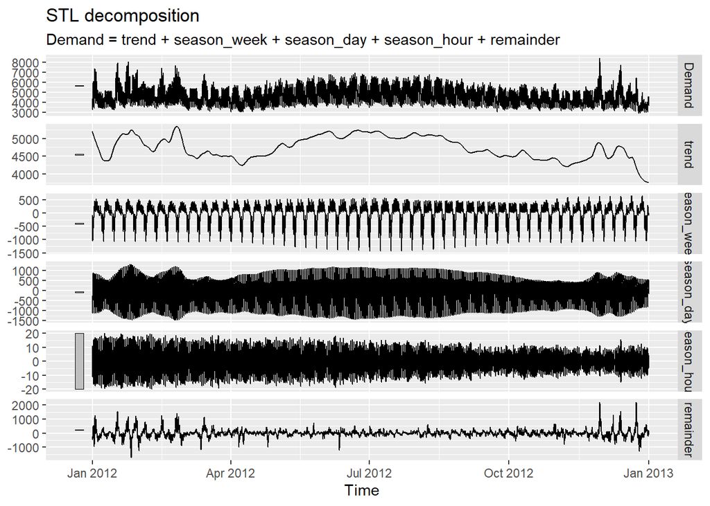

```r
# Decomposing the vic_elec data into trend, seasonal, and remainder(residuals) using the feasts package to gain an understanding of the periodicities that are present in the data

# For a single year:

decomp <- vic_elec %>%
  filter(year(Date) == 2012) %>%
  model(STL(Demand)) %>%
  components()

decomp %>% autoplot()
```

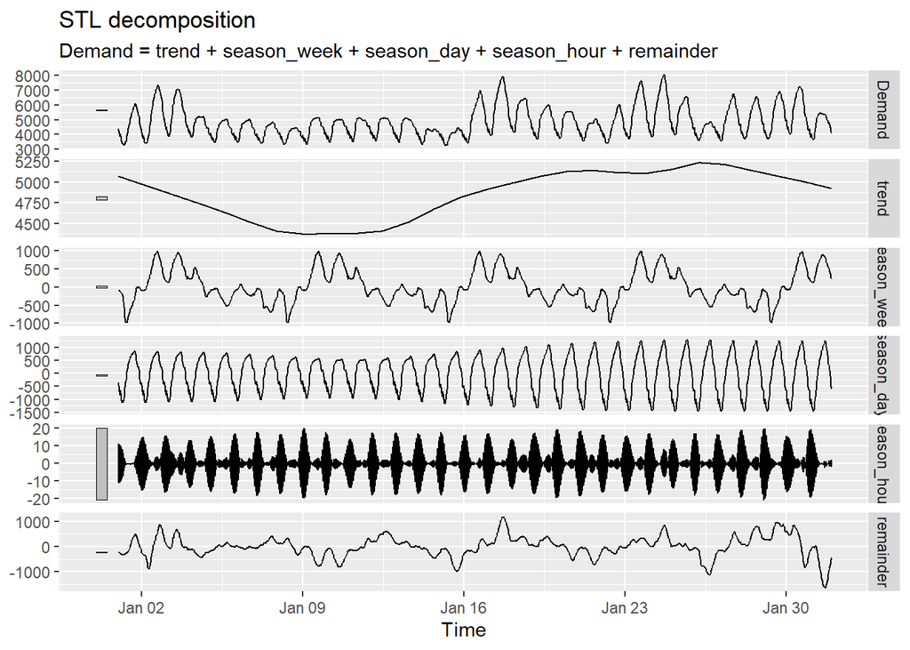

```r
# For a single month

decomp <- vic_elec %>%
  filter(year(Date) == 2012, month(Date) == 1) %>%
  model(STL(Demand)) %>%
  components()

decomp %>% autoplot()
```

**Data Preparation**

```r
# We split the data into training, validation, and test sets based on years (since the data set covers three years of hourly data)
# The split will help us evaluate how well the model generalizes to new data

demand_hourly <- vic_elec %>%
  index_by(Hour = floor_date(Time, "hour")) %>%
  summarise(Demand = sum(Demand))

demand_hourly %>% head
```

```
## # A tsibble: 6 x 2 [1h] <Australia/Melbourne>
##   Hour                Demand
##   <dttm>               <dbl>
## 1 2012-01-01 00:00:00  8646.
## 2 2012-01-01 01:00:00  7927.
## 3 2012-01-01 02:00:00  7902.
## 4 2012-01-01 03:00:00  7256.
## 5 2012-01-01 04:00:00  6793.
## 6 2012-01-01 05:00:00  6636.
```

```r
demand_train <- demand_hourly %>%
  filter(year(Hour) == 2012) %>%
  as_tibble() %>%
  select(Demand) %>%
  as.matrix()

demand_train %>% head
```

```
##        Demand
## [1,] 8646.191
## [2,] 7926.529
## [3,] 7901.827
## [4,] 7255.721
## [5,] 6792.503
## [6,] 6635.984
```

```r
demand_valid <- demand_hourly %>%
  filter(year(Hour) == 2013) %>%
  as_tibble() %>%
  select(Demand) %>%
  as.matrix()

demand_valid %>% head()
```

```
##        Demand
## [1,] 8111.219
## [2,] 7374.896
## [3,] 7049.109
## [4,] 6474.246
## [5,] 6101.232
## [6,] 6020.342
```

```r
demand_test <- demand_hourly %>%
  filter(year(Hour) == 2014) %>%
  as_tibble() %>%
  select(Demand) %>%
  as.matrix()

demand_test %>% head
```

```
##        Demand
## [1,] 8289.992
## [2,] 7587.197
## [3,] 6836.684
## [4,] 6304.355
## [5,] 6051.556
## [6,] 6043.942
```

```r
# Normalization
train_mean <- mean(demand_train)
train_sd <- sd(demand_train)
```

*Dataset*

```r
demand_dataset <- dataset(
  name = "demand_dataset",                      # Name of the dataset
  initialize = function(x,                      # Initialize with input data `x`
                        n_timesteps,            # The number of past time steps used for prediction
                        n_forecast,             # The number of time steps we want to forecast
                        sample_frac = 1) {      # Fraction of the data to sample
    self$n_timesteps <- n_timesteps             # Store number of input time steps
    self$n_forecast <- n_forecast               # Store number of forecast steps
    self$x <- torch_tensor((x - train_mean) / train_sd) # Normalize data using training mean and std

    n <- length(self$x) - self$n_timesteps - self$n_forecast + 1 # Number of available data points
    self$starts <- sort(sample.int(            # Random sampling of data points
      n = n,
      size = n * sample_frac
    ))
  },

  .getitem = function(i) {                     # Define how to get a data point
    start <- self$starts[i]                    # Start index of the input sequence
    end <- start + self$n_timesteps - 1        # End index of the input sequence
    list(
      x = self$x[start:end],                   # Input sequence (past data)
      y = self$x[(end + 1):(end + self$n_forecast)]$squeeze(2)  # Target sequence (future data)
    )
  },

  .length = function() {                       # Length of the dataset (how many samples)
    length(self$starts)
  }
)
```

```r
# Creating data sets

n_timesteps <- 7 * 24  # 7 days of hourly data (168 hours)
n_forecast <- 7 * 24   # Forecast 7 days ahead

train_ds <- demand_dataset(demand_train, n_timesteps, n_forecast, sample_frac = 1)
#train_ds[1]

valid_ds <- demand_dataset(demand_valid, n_timesteps, n_forecast, sample_frac = 1)
#valid_ds[1]

test_ds <- demand_dataset(demand_test, n_timesteps, n_forecast)
#test_ds[1]

# We use 7 * 24 because we are forecasting hourly data for an entire week (7 days × 24 hours).

batch_size <- 128

train_dl <- train_ds %>%
  dataloader(batch_size = batch_size, shuffle = TRUE)

valid_dl <- valid_ds %>%
  dataloader(batch_size = batch_size)

test_dl <- test_ds %>%
  dataloader(batch_size = length(test_ds))
```

**Model definition**

```r
# The final layers uses a multi layer perceptron, this returns n_forecast predictions for each time step

elecModel <- nn_module(
  initialize = function(input_size,            # Number of input features (1 for univariate)
                        hidden_size,           # Number of hidden units in LSTM
                        linear_size,           # Number of hidden units in MLP
                        output_size,           # Number of forecast time steps (n_forecast)
                        dropout = 0.2,         # Dropout rate
                        num_layers = 1,        # Number of LSTM layers
                        rec_dropout = 0) {     # Recurrent dropout rate
    self$num_layers <- num_layers              # Store the number of LSTM layers
    self$rnn <- nn_lstm(                       # Define the LSTM
      input_size = input_size,
      hidden_size = hidden_size,
      num_layers = num_layers,
      dropout = rec_dropout,
      batch_first = TRUE                       # Batch first format
    )
    self$dropout <- nn_dropout(dropout)        # Add dropout
    self$mlp <- nn_sequential(                 # Define the MLP for multi-step forecasting
      nn_linear(hidden_size, linear_size),     # Linear layer
      nn_relu(),                              # ReLU activation
      nn_dropout(dropout),                    # Dropout
      nn_linear(linear_size, output_size)      # Output layer producing n_forecast predictions
    )
  },

  forward = function(x) {                      # Define forward pass
    x <- self$rnn(x)[[2]][[1]][self$num_layers, , ] %>%   # Output from LSTM layer
      self$mlp()                               # Pass through MLP
  }
)
```

**Hyper parameters**

```r
input_size <- 1       # Only one feature (univariate time series)
hidden_size <- 32     # Number of units in the LSTM layer
linear_size <- 512    # Number of units in the MLP
dropout <- 0.5        # Dropout rate
num_layers <- 2       # Number of LSTM layers
rec_dropout <- 0.2    # Recurrent dropout
```

**Learning rate finder**

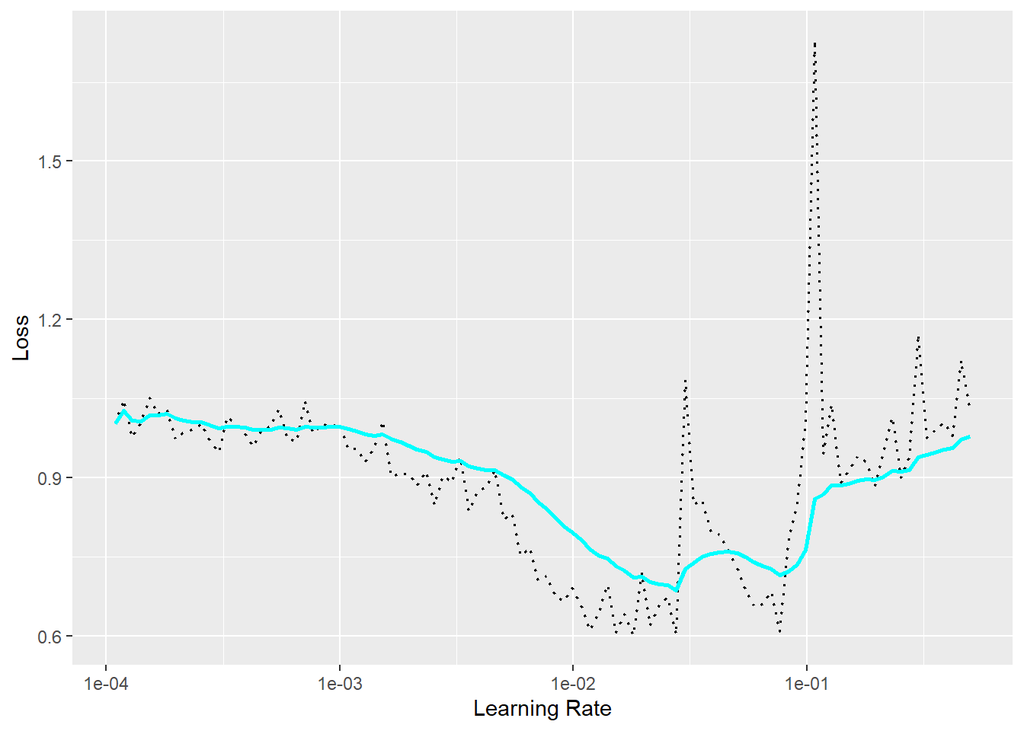

```r
elecModel <- elecModel %>%
  setup(optimizer = optim_adam, loss = nn_mse_loss()) %>%
  set_hparams(input_size = input_size,
              hidden_size = hidden_size,
              linear_size = linear_size,
              output_size = n_forecast,
              num_layers = num_layers,
              rec_dropout = rec_dropout)


# Find learning rate
rates_and_loss <- elecModel %>% lr_finder(
  train_dl,
  start_lr = 1e-4,
  end_lr = 0.5
)

rates_and_loss %>% plot()
```

**Model training**

```r
# Train the model with early stopping and learning rate scheduling
fittedElec <- elecModel %>%
  fit(train_dl, epochs = 100, valid_data = valid_dl,
      callbacks = list(
        luz_callback_early_stopping(patience = 3),
        luz_callback_lr_scheduler(
          lr_one_cycle,
          max_lr = 0.01,
          epochs = 100,
          steps_per_epoch = length(train_dl),
          call_on = "on_batch_end")
      ),
      verbose = TRUE)
```

**Model Evaluation**

```r
fittedElec %>%
  evaluate(test_dl)
```

```
## A `luz_module_evaluation`
## ── Results ─────────────────────────────────────────────────────────────────────
## loss: 0.4833
```

```r
# Visualizing the last month only

demand_viz <- demand_hourly %>%
  filter(year(Hour) == 2014, month(Hour) == 12)

demand_viz_matrix <- demand_viz %>%
  as_tibble() %>%
  select(Demand) %>%
  as.matrix()

demand_viz_matrix %>% head
```

```
##        Demand
## [1,] 9140.743
## [2,] 8456.402
## [3,] 7817.163
## [4,] 7388.645
## [5,] 7331.072
## [6,] 7797.262
```

```r
n_obs <- nrow(demand_viz_matrix)
n_obs
```

```
## [1] 744
```

```r
viz_ds <- demand_dataset(demand_viz_matrix, n_timesteps, n_forecast)   # prepares the data set for making predictions
# viz_ds[1]
length(viz_ds)
```

```
## [1] 409
```

```r
viz_dl <- dataloader(viz_ds, batch_size = length(viz_ds))
```

```r
# Making predictions

preds <- predict(fittedElec, viz_dl)
preds <- preds$to(device = "cpu") %>% as.matrix()

preds %>% head(2)
```

[output not shown]

[output cut: 20 more lines]

[output not shown]

Three sample indices (1, 201, and 401) are chosen from the predictions to visualize.

For each index, the corresponding prediction values are extracted, and NA is added to align the predictions with the original time series data. This is done using rep(NA, n_timesteps + cur_obs - 1) before the prediction and after the prediction.

A new dataframe pred_ts is created, adding columns p1, p2, and p3 for the three selected predictions.

These predictions are de-normalized and combined with the actual demand values.

```r
example_preds <- vector(mode = "list", length = 3)
example_indices <- c(1, 201, 401)

for (i in seq_along(example_indices)) {
  cur_obs <- example_indices[i]
  example_preds[[i]] <- c(
    rep(NA, n_timesteps + cur_obs - 1),
    preds[cur_obs, ],
    rep(NA, n_obs - cur_obs + 1 - n_timesteps - n_forecast)
  )
}

example_preds[[1]]
```

[output not shown]

[output cut: 109 more lines]

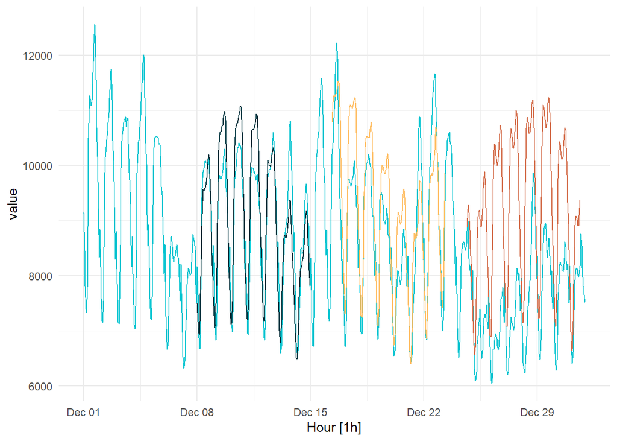

```r
# combining predictions and actual values

pred_ts <- demand_viz %>%
  select(Demand) %>%
  add_column(
    p1 = example_preds[[1]] * train_sd + train_mean,
    p2 = example_preds[[2]] * train_sd + train_mean,
    p3 = example_preds[[3]] * train_sd + train_mean
  ) %>%
  pivot_longer(-Hour) %>%
  update_tsibble(key = name)

#pred_ts %>% View()

pred_ts %>%
  autoplot() +
  scale_colour_manual(
    values = c(
      "#08c5d1", "#00353f", "#ffbf66", "#d46f4d"
    )
  ) +
  theme_minimal() +
  theme(legend.position = "None")
```

The daily and weekly rythms are present in the above plot. Though there are some mini-trends that develop over the month